# Códigos R Markdown

Vinícius Aquino de Laet

25/05/2021

# Cabeçalhos:

Para se fazer cabeçalhos, deve-se usar o símbolo #, caso queira usar o símbolo como exemplo, use o símbolo / (ao contrário), como foi feito abaixo usando a palavra maçã.

Obs. Dê sempre um espaço após o símbolo inicial e o que for escrever, e para colocar algo e uma nova linha escreva saltando o espaço de uma linha como foi feito no presente código.

## Maçã

## maçã

# Formatação de Texto:

## Itálico:

Para se colocar algo em itálico, deve-se colocar a palavra, frase ou o que desejar ser colocado em itálico entre o símbolo *, veja exemplo abaixo em que o sujeito da frase está em itálico.

* = *Itálico*

*Maria* gosta de maçã.

## Negrito:

Para se colocar algo em negrito, deve-se colocar o que queira negritar entre o símbolo *, só que para que o símbolo deve ser colocado 2 vezes. Veja exemplo em que a palavra torta fica em negrito.

** = **Negrito**

Maria gosta de **torta** de maçã.

## Formatação em Código:

Para se colocar algo como se fosse um código, deve-se usar o símbolo de crase (`), colocando a palavra ou função desejada entre esse símbolo. Veja exemplo em que o código de histograma é colocado nessa formatação.

` = `Código`

Para se obter um histograma das variáveis deve-se usar o comando `hist()`.

## Listas Ordenadas, Não Ordenadas e Sublistas:

### Lista Ordenada:

Para se criar uma lista ordenada, deve-se colocar o número e em seguida um ponto, espaço e depois o que quer ser colocado naquela lista. Veja exemplo:

Obs. Nesse caso não se usa o espaço.

1. Maçã
2. Laranja
3. Mamão
4. Morango

### Lista Não Ordenada:

Para se criar uma lista não ordenada, deve-se colocar o asterisco (*) e em seguida espaço e depois o quedeseja colocar naquela lista. Veja exemplo:

Obs. Se o espaço não for colocado após o símbolo, a lista aparecerá com os códigos e as palavras na mesma linha, ou seja, uma na frente da outra.

- Maçã
- Banana
- Uva
- Limão

### Sublista:

Para se criar uma sublista, deve-se digitar usar a tecla tab e adicionar o símbolo + seguido de espaço e, em seguida o que quer escrever. Veja exemplo:

Obs. A tecla tab deve ser usada apenas uma vez, haja vista que quando você der enter, a próxima linha já virá com o espaço introduzido pela tecla tab pois, o programa pressupõe que você continuará a sublista.Assim, quando não quiser continuar a sublista, após dar enter apague o espaço para continuar a escrita do texto.

- Homens
  - Pedro
  - Ítalo
  - Geovane
- Mulheres
  - Letícia
  - Ana Clara
  - Patrícia

## Criando Links Externos para Sites na Internet:

Para se criar links externos, existem 2 modos, o primeiro consiste em colar o link no cursor. Já o segundo, consiste em criar uma palavra na qual haverá um *hiperlink*, ou seja, você cria um link dentro de uma palavra, dessa forma ao se clicar na palavra, você será redirecionado para o link.Veja os exemplos abaixo.

### Link:

O link será apenas colado na frente do nome da página.

YouTube https://www.youtube.com/

### Hiperlink:

Para se colocar um hiperlink, ou seja, uma palavra contendo um link, deve-se colocar a palavra na qual quer inserir o hiperlink entre colchetes e, em seguida colocar o link dentro de parênteses.

[YouTube](https://www.youtube.com/)

## Escrevendo Fórmulas Matemáticas no Formato LaTex:

Para se colocar as fórmulas matemáticas no documento,deve-se usar `$$ LaTex $$` (formatação em bloco) ou `$ LaTex $` (formatação em linha). Ou seja, deve ser usado o símbolo $ antes e depois da equação, ficando assim, a equação na linha entre o símbolo inicial e o final.

Obs. A medida que o código for digitado, a equação resultante dele irá aparecendo abaixo.

### Exemplos:

Obs. Os exemplos são meramente ilustrativos.

Atenção: A formatação em linha não deixa espaço entre o símbolo e a equação.

$$\sqrt{\frac{a}{b}}$$

$$\forall x \exists y(F(x,y) \to Q(x,y))$$

$$s = \sqrt{\frac {\sum_{i=1}^N(x-\bar{x})²}{N-1}}$$

$$5=3+2$$
$ax²+bx+c=0$

## Executar Códigos do R:

É possível executar códigos em bloco ou em linha (inline) no R.

### Códigos em Bloco:

Para se colocar um código em bloco, de maneira análoga à escrita em bloco de fórmulas matemáticas, deve-se colocar antes e depois do código o símbolo de execução de códigos em R. O símbolo que deve ser utilizado é a crase repetida 3 vezes e, em seguida um conjunto de chaves contendo a letra r e um espaço após a letra.

- Em Bloco:

```{r } ```

- Em linha:

``r ``

Obs. O R Markdown vai mostrar o código que você inserir, mesmo que seja uma variável, importação de bibliotecas ou códigos externos, o R Markdown vai funcionar como se você tivesse executando um código normalmente no R Studio, desde que você utilize o código supracitado.

#### Exemplo:

```r
#Definindo a variável x, temos:
  x <- c("maçã")
str(x)
```

```
##  chr "maçã"
```

### Códigos Inline:

Para se colocar um código inline, deve-se colocar a crase 2 vezes no ínicio e 2 vezes no fim, colocando entre elas, na mesma linha, a letra r, espaço e o código a ser executado naquela linha.

#### Exemplo:

`maçã`

## Configurando os Blocos de Código:

Podemos configurar os blocos de código usando flags. Elas podem possuir valor `TRUE` ou `FALSE`.

### Flag

- **Flag** é o emprego de uma variável para sinalizar algum tipo de evento, situação ou estado do programa.

#### Eval:

O `eval` é responsável pela habilitação ou não do código. Com o comando `eval = False` o código não será executado com possíveis resultados não sendo armazenados.

```{r eval = TRUE ou FALSE} ```

```r
str(x <- "cavalo")
```

```
##  chr "cavalo"
```

`cavalo`

Caso você coloque FALSE, o R Markdown não executará o código pois, ele entenderá que a variável x não existe pois, o FALSE faz com que ela não seja armazenada.

#### Echo:

O `echo`mostra o código utilizado junto ao resultado.

```{r echo = TRUE ou FALSE} ```

```r
str(x <- "ovelha")
```

```
##  chr "ovelha"
```

O comando FALSE vai apenas omitir o comando utilizado.

#### Warning:

O `warning` vai exibir possíveis advertências no código.

```{r warning = TRUE ou FALSE} ```

```r
warning("Lágrimas não são argumentos")
```

O comando FALSE vai apenas omitir o comando utilizado.

#### Error:

O `error`oculta ou não as mensagens de erro de seu código. O `FALSE` não permite a execução do código.

```{r error = TRUE ou FALSE} ```

```r
str(
```

```
## Error: <text>:2:0: unexpected end of input
## 1: str(
##    ^
```

Caso eu não queira mostrar o código é possível juntar configurações num mesmo código apenas usando a vígula como separador, como feito abaixo impedindo a visualização do código utilizado.

```
## Error: <text>:2:0: unexpected end of input
## 1: str(
##    ^
```

## Nomeando e Executando Blocos de Código:

Após o comando `{r`, você pode nomear o bloco de código.

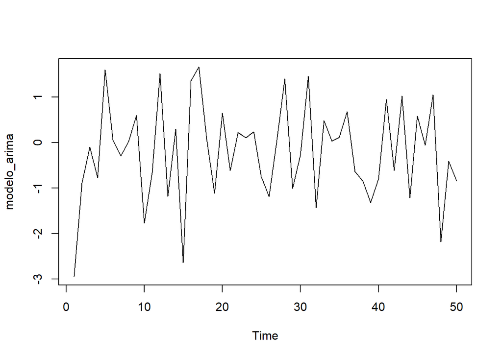

```r
#Criando o Código:
modelo_arima <- arima.sim(model = list(c(0,0,0)), n = 50)

plot(modelo_arima)
```

Essa função é útil para guardar determinado bloco de código e utilizar depois quando for preciso.

## Gerando Documentos em Outros Formatos

Para gerar PDFs, PPTs e afins, insira o tipo de dado no `output`, no bloco inicial do documento.

## Possíveis Configurações

- `html_document`
- `pdf_document` - caso não funcione, baixe e instale o pacote [MiKTeX](https://miktex.org/2.9/setup)
- `word_document`
- `beamer_presentation`
- `slidy_presentation`
- `ioslides_presentation`
- `word_document`

## Arquivo com os Códigos no Github:

[Github](https://github.com/Viniciusaqui/R-Markdown)